# Лабораторная работа № 5

### Задание.

1. Добавить проверку на выбросы и избавиться от них.
2. Повторно провести все тесты и сравнить результаты с выбросами и без.
3. Открыть документ https://www.sheffield.ac.uk/polopoly_fs/1.547015!/file/Diet_data_description.docx и попытаться выполнить задания из него.

### Избавляемся от выбросов. Диаграммы размаха по типу диет:

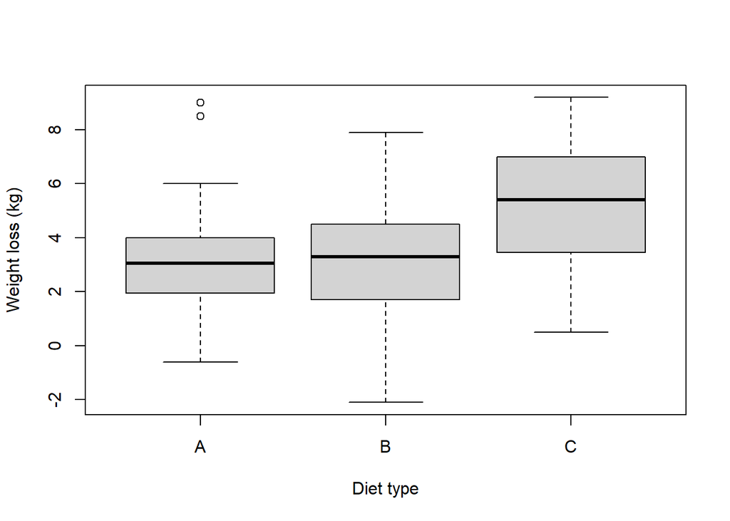

```r
boxplot(weight.loss ~ diet.type,data=data,col="light gray", ylab = "Weight loss (kg)", xlab = "Diet type")
```

Диаграмма размаха показыват что в выборке, соответствующей диете А присутствуют выбросы. Построим гистрограммы распределения значений потери веса по каждой группе диеты:

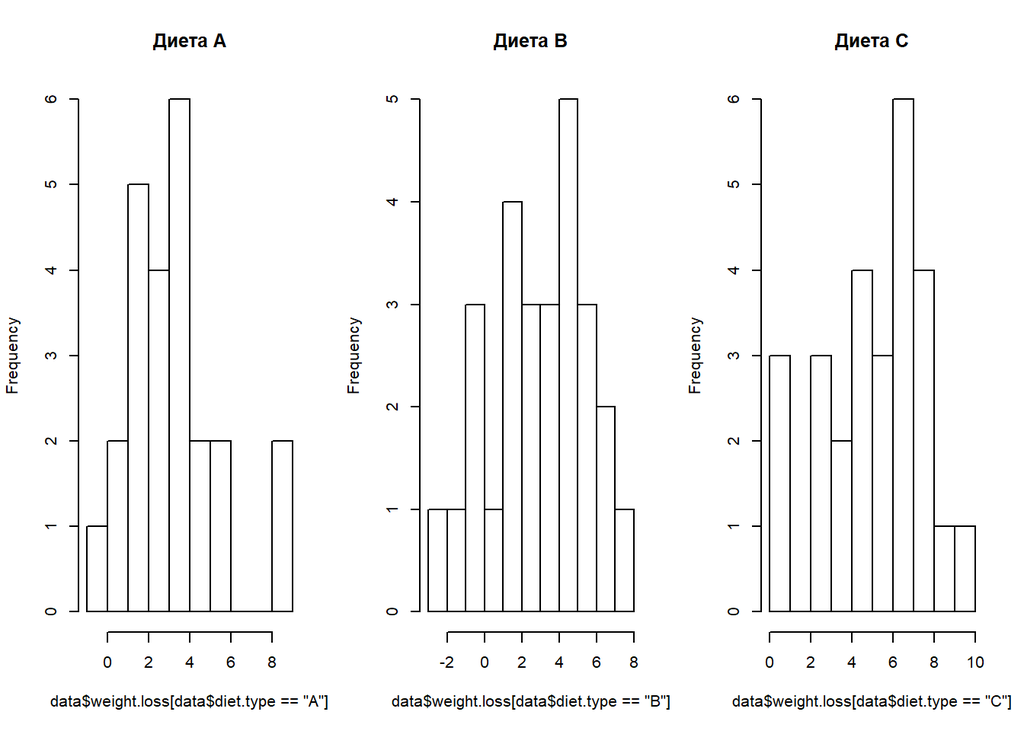

```r
par(mfrow=c(1,3))
hist(data$weight.loss[data$diet.type=="A"], breaks = 10, main="Диета А")
hist(data$weight.loss[data$diet.type=="B"], breaks = 10, main="Диета В")
hist(data$weight.loss[data$diet.type=="C"], breaks = 10, main="Диета С")
```

Исключим из выборки наблюдения, имеющие тип диеты A и величину потери веса больше 6 кг:

```r
data.noout <- data[!(data$diet.type == "A" & data$weight.loss > 6.0),]
```

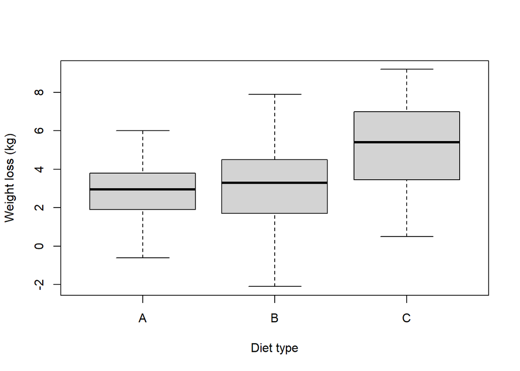

```r
boxplot(weight.loss ~ diet.type,data=data.noout,col="light gray", ylab = "Weight loss (kg)", xlab = "Diet type")
```

Теперь в выборке отсутствуют выбросы.

### Повторное проведение тестов на выборке без выбросов (One-way ANOVA)

```r
table(data.noout$diet.type)
```

```
##
##  A  B  C
## 22 27 27
```

График групповых средних:

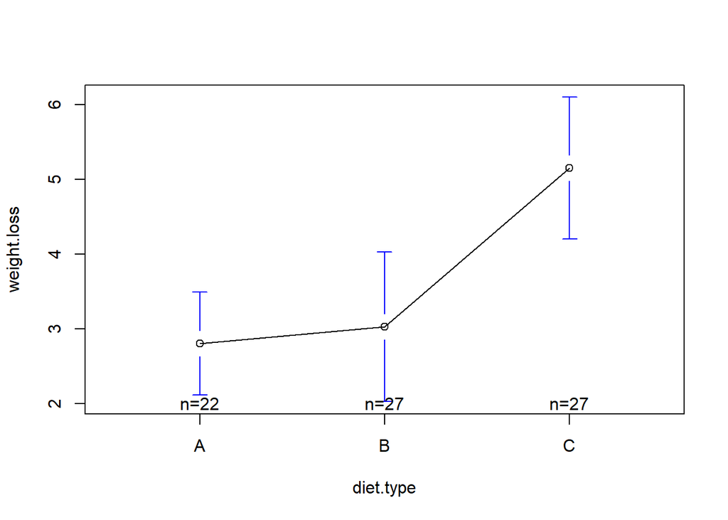

```r
plotmeans(weight.loss ~ diet.type, data=data.noout)
```

```r
aggregate(data.noout$weight.loss, by = list(data.noout$diet.type), FUN=sd)
```

```
##   Group.1        x
## 1       A 1.550569
## 2       B 2.523367
## 3       C 2.395568
```

Подгонка ANOVA модели:

```r
fit.noout <- aov(weight.loss ~ diet.type, data=data.noout)
summary(fit.noout)
```

```
##             Df Sum Sq Mean Sq F value   Pr(>F)
## diet.type    2   86.5   43.26   8.645 0.000427 ***
## Residuals   73  365.2    5.00
## ---
## Signif. codes:  0 '***' 0.001 '**' 0.01 '*' 0.05 '.' 0.1 ' ' 1
```

Попарные различия между средними значениями для всех групп:

```r
TukeyHSD(fit.noout)
```

```
##   Tukey multiple comparisons of means
##     95% family-wise confidence level
##
## Fit: aov(formula = weight.loss ~ diet.type, data = data.noout)
##
## $diet.type
##          diff        lwr      upr     p adj
## B-A 0.2213805 -1.3156340 1.758395 0.9367018
## C-A 2.3436027  0.8065882 3.880617 0.0014162
## C-B 2.1222222  0.6657364 3.578708 0.0023769
```

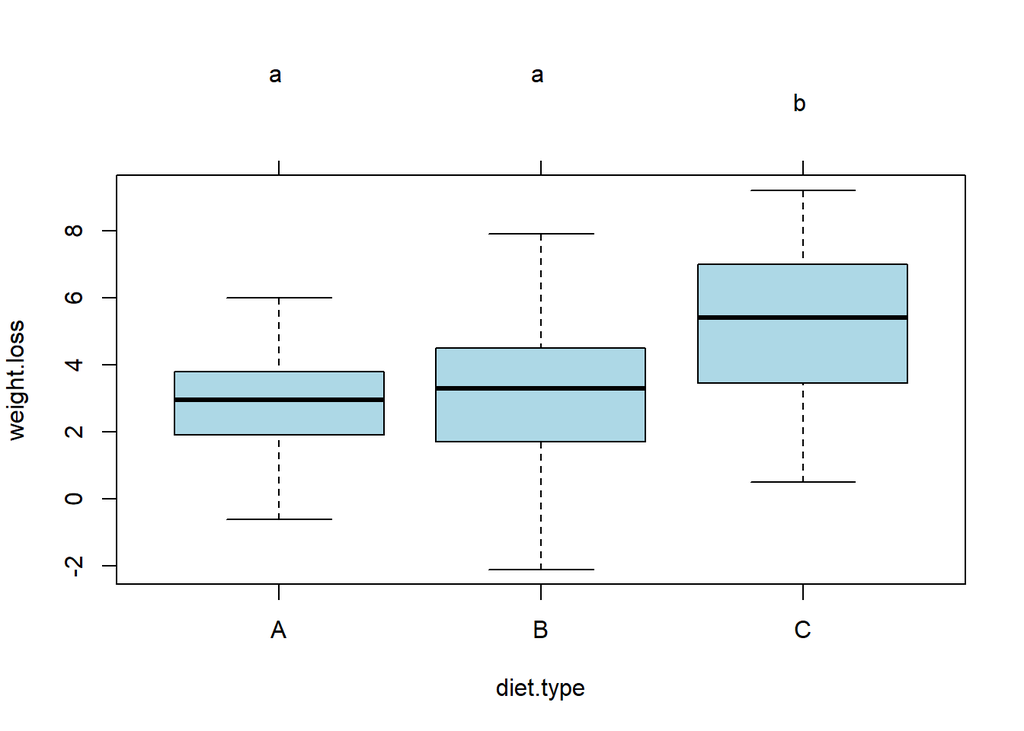

```r
library(multcomp)
par(mar=c(5,4,6,2))
tuk <- glht(fit.noout, linfct=mcp(diet.type="Tukey"))
plot(cld(tuk, level=.05),col="light blue")
```

### Анализ зависимости величины потери веса от пола

Подготовка данных (исключаем наблюдения, в которых неизвестно значение пола):

```r
data.noout.gender <- data.noout [!(is.na(data.noout$gender)),]
data.noout.gender$gender <- factor(c("Female", "Male")[as.ordered(data.noout.gender$gender)])
```

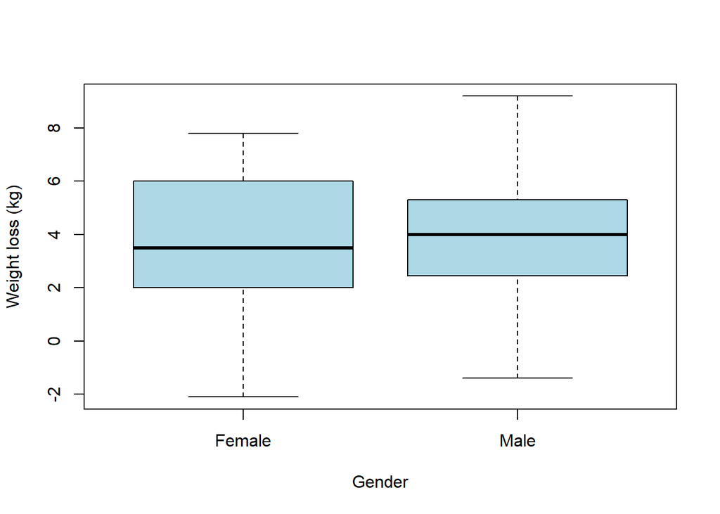

```r
boxplot(weight.loss ~ gender,data=data.noout.gender,col="light blue", ylab = "Weight loss (kg)", xlab = "Gender")
```

```r
table(data.noout.gender$gender)
```

```
##
## Female   Male
##     42     32
```

Уменьшилось число наблюдений в группе “B”.

График групповых средних по полу:

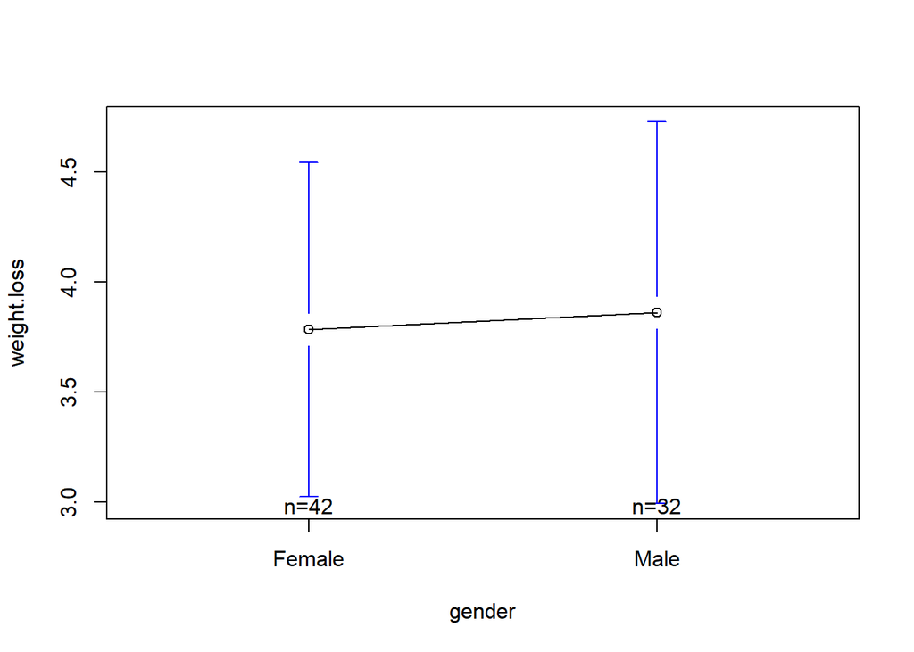

```r
plotmeans(weight.loss ~ gender, data=data.noout.gender)
```

```r
aggregate(data.noout.gender$weight.loss, by = list(data.noout.gender$gender), FUN=sd)
```

```
##   Group.1        x
## 1  Female 2.440104
## 2    Male 2.404144
```

Среднее значение потерянного веса мужчинами немного превышает среднее значение потерянного веса женщинами (среднеквадратичное отклонение отличается на сотые доли).

Подгонка ANOVA модели:

```r
fit.noout.gender <- aov(weight.loss ~ gender, data=data.noout.gender)
summary(fit.noout.gender)
```

```
##             Df Sum Sq Mean Sq F value Pr(>F)
## gender       1    0.1   0.105   0.018  0.894
## Residuals   72  423.3   5.879
```

Попарные различия между средними значениями для всех групп:

```r
TukeyHSD(fit.noout.gender)
```

```
##   Tukey multiple comparisons of means
##     95% family-wise confidence level
##
## Fit: aov(formula = weight.loss ~ gender, data = data.noout.gender)
##
## $gender
##                   diff       lwr      upr     p adj
## Male-Female 0.07604167 -1.058133 1.210217 0.8940496
```

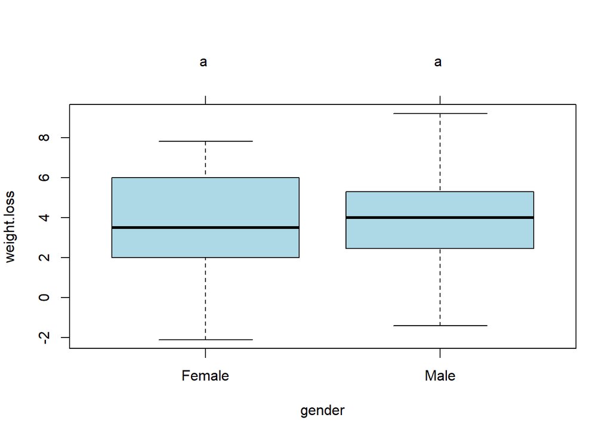

```r
library(multcomp)
par(mar=c(5,4,6,2))
tuk <- glht(fit.noout.gender, linfct=mcp(gender="Tukey"))
plot(cld(tuk, level=.05),col="light blue")
```

Результаты показывают, что разница между потерей веса мужчинами и женщинами составляет 0.07604167, т.е. в общем диеты “А”, “В” и “С” в плане потери веса действуют чуть-чуть лучше на мужчин, но статистически эта разница является незначительной.

### Двухфакторный дисперсионный анализ зависимости величины потери веса от пола и типа диеты (two-way ANOVA).

Диаграмма размаха значений потери веса по типу диеты и полу:

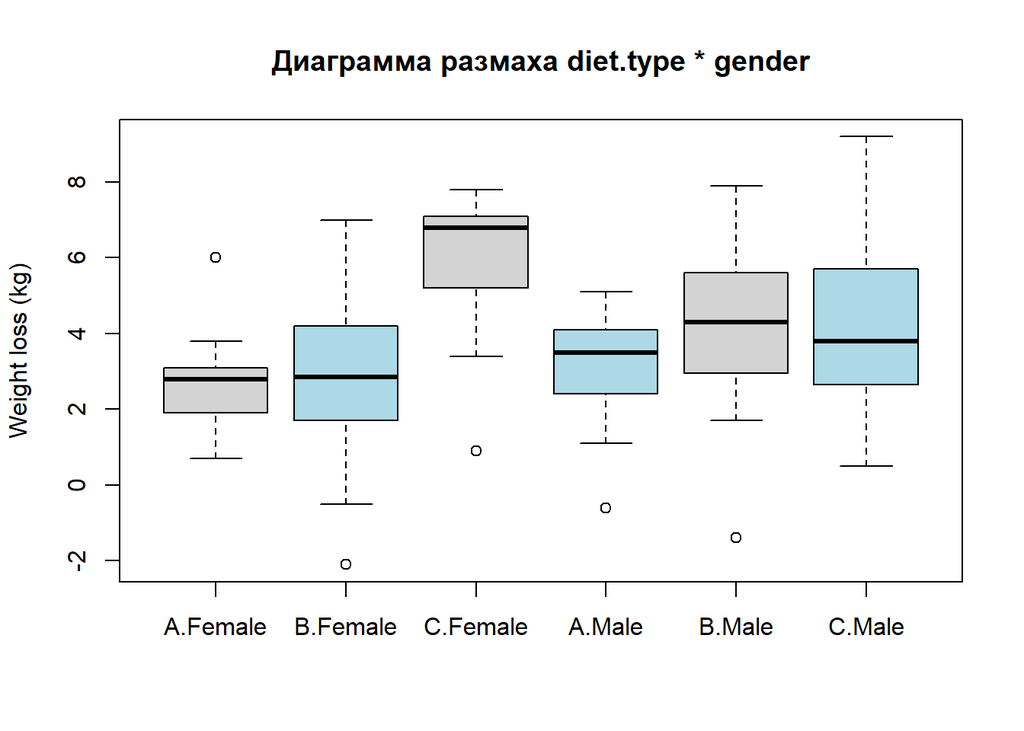

```r
boxplot(weight.loss ~ diet.type * gender, data=data.noout.gender,col=c("light gray", "light blue"), ylab = "Weight loss (kg)", main="Диаграмма размаха diet.type * gender")
```

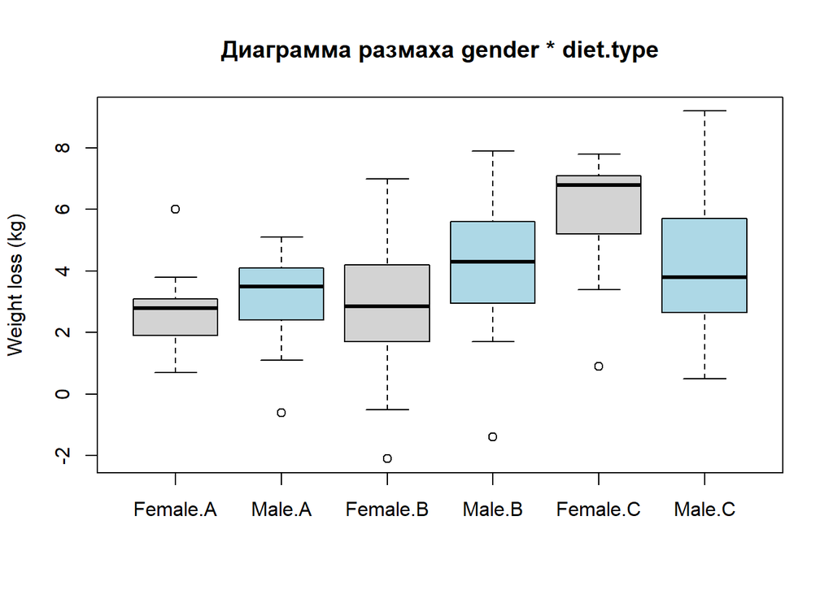

```r
boxplot(weight.loss ~ gender * diet.type, data=data.noout.gender,col=c("light gray", "light blue"), ylab = "Weight loss (kg)", main="Диаграмма размаха gender * diet.type")
```

Если проанализировать вторую диаграмму размаха по каждой диете, то видим, что диета “А” наиболее эффективна для мужчин, диета “В” - тоже для мужчин, а диета “С” - для женщин.

График групповых средних для двухфакторного дисперсионного анализа:

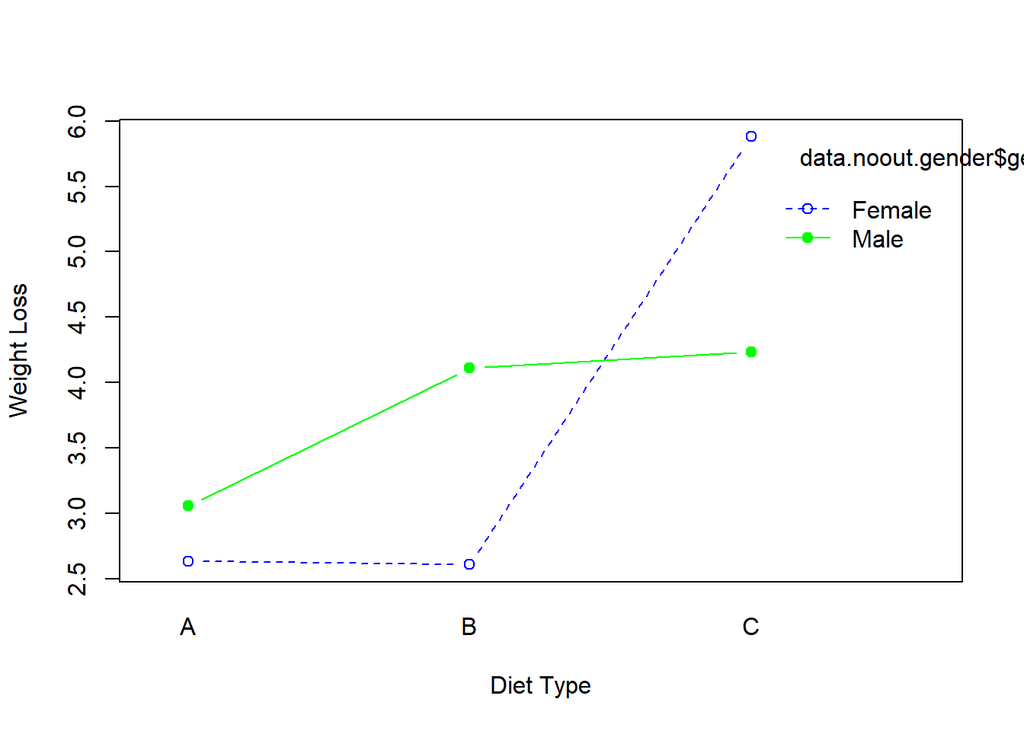

```r
interaction.plot(x.factor = data.noout.gender$diet.type,
                 trace.factor = data.noout.gender$gender,
                 response = data.noout.gender$weight.loss,
                 fun = mean,
                 type = "b", legend = TRUE,
                 xlab = "Diet Type", ylab="Weight Loss",
                 pch=c(1,19), col = c("blue","green"))
```

Подгонка ANOVA модели:

```r
data.noout.gender$type_gender <- interaction(data.noout.gender$diet.type,data.noout.gender$gender)
fit.two_way_anova <- aov(weight.loss ~ type_gender, data=data.noout.gender)
summary(fit.two_way_anova)
```

```
##             Df Sum Sq Mean Sq F value   Pr(>F)
## type_gender  5  110.9  22.172   4.824 0.000781 ***
## Residuals   68  312.5   4.596
## ---
## Signif. codes:  0 '***' 0.001 '**' 0.01 '*' 0.05 '.' 0.1 ' ' 1
```

Попарные сравнения:

```r
TukeyHSD(fit.two_way_anova)
```

```
##   Tukey multiple comparisons of means
##     95% family-wise confidence level
##
## Fit: aov(formula = weight.loss ~ type_gender, data = data.noout.gender)
##
## $type_gender
##                          diff        lwr        upr     p adj
## B.Female-A.Female -0.02362637 -2.4451450  2.3978922 1.0000000
## C.Female-A.Female  3.24923077  0.8668930  5.6315685 0.0021219
## A.Male-A.Female    0.42478632 -2.3014282  3.1510009 0.9973974
## B.Male-A.Female    1.47832168 -1.0972831  4.0539264 0.5474555
## C.Male-A.Female    1.60256410 -0.9142395  4.1193677 0.4308788
## C.Female-B.Female  3.27285714  0.9365444  5.6091698 0.0014776
## A.Male-B.Female    0.44841270 -2.2376755  3.1345009 0.9963916
## B.Male-B.Female    1.50194805 -1.0311457  4.0350418 0.5115826
## C.Male-B.Female    1.62619048 -0.8470916  4.0994726 0.3943541
## A.Male-C.Female   -2.82444444 -5.4752652 -0.1736237 0.0301179
## B.Male-C.Female   -1.77090909 -4.2665743  0.7247561 0.3094937
## C.Male-C.Female   -1.64666667 -4.0816010  0.7882676 0.3625754
## B.Male-A.Male      1.05353535 -1.7722490  3.8793197 0.8823882
## C.Male-A.Male      1.17777778 -1.5945169  3.9500724 0.8126199
## C.Male-B.Male      0.12424242 -2.5000883  2.7485732 0.9999925
```

Попарные сравнения подверждают вышесказанный вывод о том, что диета “С” для женщин является эффективнее диет “А” и “В” (т.к. C.Female-A.Female = 3.249 и C.Female-B.Female = 3.273).

Для мужчин справедливо следующее: диеты “В” и “С” эффективны примерно одинаково (диета “С” чуть эффективнее, т.к. C.Male-B.Male = 0.124), но по сравнению с диетой “A” обеспечивают для мужчин большую потерю веса (поскольку B.Male-A.Male = 1.054 и C.Male-A.Male = 1.178)

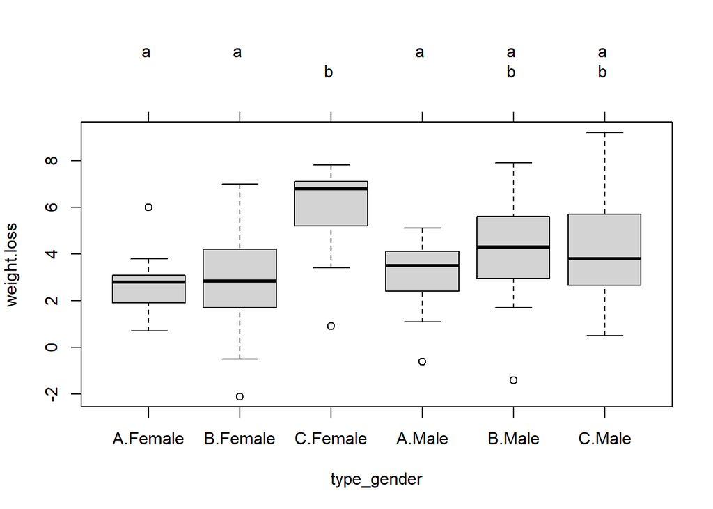

```r
par(mar=c(5,4,6,2))
tuk <- glht(fit.two_way_anova, linfct=mcp(type_gender="Tukey"))
plot(cld(tuk, level=.05),col="lightgrey")
```

### ANCOVA (analysis of covariance - ковариационный анализ)

Добавим к однофакторному анализу ANOVA еще одну непрерыную переменную - рост человека.

ANOVA использует для сравнения наблюдений по группам только категориальные переменные, а ANCOVA сравнивает значения непрерывной переменной, используя интервальные (ковариаты) и номинальные переменные.

В данном случае ковариатой будет являться значение роста человека.

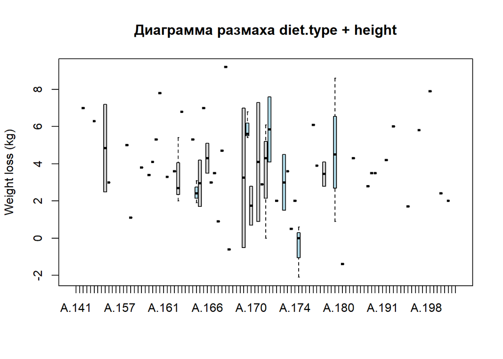

```r
boxplot(weight.loss ~ diet.type + height, data=data.noout,col=c("light gray", "light blue"), ylab = "Weight loss (kg)", main="Диаграмма размаха diet.type + height")
```

```r
fit.ancova <- aov(weight.loss ~ diet.type + height, data=data.noout)
summary(fit.ancova)
```

```
##             Df Sum Sq Mean Sq F value   Pr(>F)
## diet.type    2   86.5   43.26   8.529 0.000474 ***
## height       1    0.1    0.10   0.020 0.887837
## Residuals   72  365.1    5.07
## ---
## Signif. codes:  0 '***' 0.001 '**' 0.01 '*' 0.05 '.' 0.1 ' ' 1
```

При добавлении ковариаты “рост человека” видим, что значение p-value является очень “большим”, т.е. рост человека оказывает слабое влияние на значение потерянного им веса.